# Session 6: Homework 3

2020-10-11

# 1 Youth Risk Behavior Surveillance

Every two years, the Centers for Disease Control and Prevention conduct the [Youth Risk Behavior Surveillance System (YRBSS)](https://www.cdc.gov/healthyyouth/data/yrbs/index.htm) survey, where it takes data from high schoolers (9th through 12th grade), to analyze health patterns.

## 1.1 Load the data

This data is part of the `openintro` textbook and we can load and inspect it. There are observations on 13 different variables, some categorical and some numerical.

```r
data(yrbss)
glimpse(yrbss)
```

```
## Rows: 13,583
## Columns: 13
## $ age                      <int> 14, 14, 15, 15, 15, 15, 15, 14, 15, 15, 15...
## $ gender                   <chr> "female", "female", "female", "female", "f...
## $ grade                    <chr> "9", "9", "9", "9", "9", "9", "9", "9", "9...
## $ hispanic                 <chr> "not", "not", "hispanic", "not", "not", "n...
## $ race                     <chr> "Black or African American", "Black or Afr...
## $ height                   <dbl> NA, NA, 1.73, 1.60, 1.50, 1.57, 1.65, 1.88...
## $ weight                   <dbl> NA, NA, 84.4, 55.8, 46.7, 67.1, 131.5, 71....
## $ helmet_12m               <chr> "never", "never", "never", "never", "did n...
## $ text_while_driving_30d   <chr> "0", NA, "30", "0", "did not drive", "did ...
## $ physically_active_7d     <int> 4, 2, 7, 0, 2, 1, 4, 4, 5, 0, 0, 0, 4, 7, ...
## $ hours_tv_per_school_day  <chr> "5+", "5+", "5+", "2", "3", "5+", "5+", "5...
## $ strength_training_7d     <int> 0, 0, 0, 0, 1, 0, 2, 0, 3, 0, 3, 0, 0, 7, ...
## $ school_night_hours_sleep <chr> "8", "6", "<5", "6", "9", "8", "9", "6", "...
```

## 1.2 Exploratory Data Analysis

We first start with analyzing the `weight` of participants in kilograms. Using visualization and summary statistics, describe the distribution of weights. How many observations are we missing weights from?

```r
skim(yrbss)
```

Data summary

| Name | yrbss |
| --- | --- |
| Number of rows | 13583 |
| Number of columns | 13 |
| _______________________ |  |
| Column type frequency: |  |
| character | 8 |
| numeric | 5 |
| ________________________ |  |
| Group variables | None |

**Variable type: character**

| skim_variable | n_missing | complete_rate | min | max | empty | n_unique | whitespace |
| --- | --- | --- | --- | --- | --- | --- | --- |
| gender | 12 | 1.00 | 4 | 6 | 0 | 2 | 0 |
| grade | 79 | 0.99 | 1 | 5 | 0 | 5 | 0 |
| hispanic | 231 | 0.98 | 3 | 8 | 0 | 2 | 0 |
| race | 2805 | 0.79 | 5 | 41 | 0 | 5 | 0 |
| helmet_12m | 311 | 0.98 | 5 | 12 | 0 | 6 | 0 |
| text_while_driving_30d | 918 | 0.93 | 1 | 13 | 0 | 8 | 0 |
| hours_tv_per_school_day | 338 | 0.98 | 1 | 12 | 0 | 7 | 0 |
| school_night_hours_sleep | 1248 | 0.91 | 1 | 3 | 0 | 7 | 0 |

**Variable type: numeric**

| skim_variable | n_missing | complete_rate | mean | sd | p0 | p25 | p50 | p75 | p100 | hist |
| --- | --- | --- | --- | --- | --- | --- | --- | --- | --- | --- |
| age | 77 | 0.99 | 16.16 | 1.26 | 12.00 | 15.0 | 16.00 | 17.00 | 18.00 | ▁▂▅▅▇ |
| height | 1004 | 0.93 | 1.69 | 0.10 | 1.27 | 1.6 | 1.68 | 1.78 | 2.11 | ▁▅▇▃▁ |
| weight | 1004 | 0.93 | 67.91 | 16.90 | 29.94 | 56.2 | 64.41 | 76.20 | 180.99 | ▆▇▂▁▁ |
| physically_active_7d | 273 | 0.98 | 3.90 | 2.56 | 0.00 | 2.0 | 4.00 | 7.00 | 7.00 | ▆▂▅▃▇ |
| strength_training_7d | 1176 | 0.91 | 2.95 | 2.58 | 0.00 | 0.0 | 3.00 | 5.00 | 7.00 | ▇▂▅▂▅ |

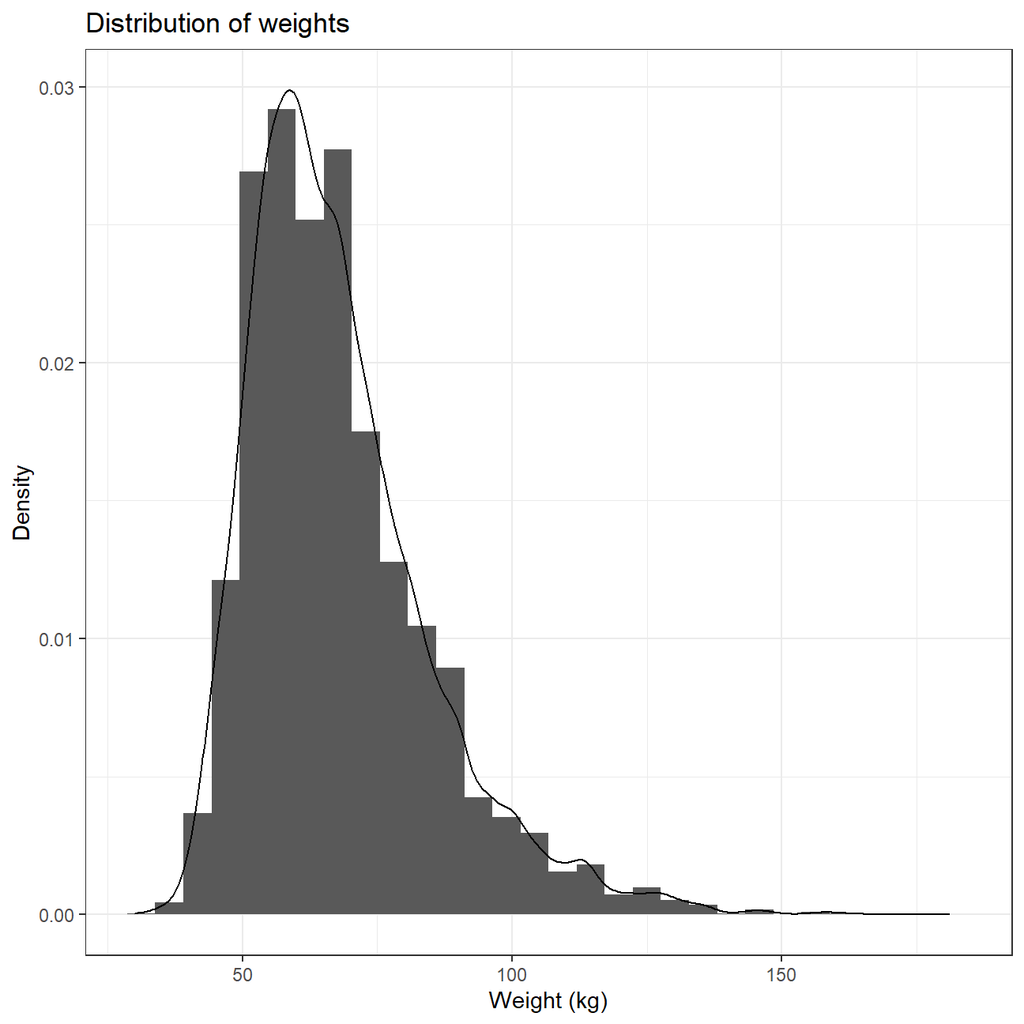

```r
yrbss %>% filter(!is.na(weight)) %>%
ggplot(aes(x=weight))+
  geom_histogram(aes(y=..density..))+
  geom_density()+
  theme_bw()+
  labs (
    title= "Distribution of weights",
    x = "Weight (kg)",
    y = "Density"
  )+
  NULL
```

> The distribution of weights is heavily right skewed. Additionally, mean and median are different as well as not quite symmetricall lower and upper quartiles.

> We are missing 1004 observations for the variable “weight”.

Next, we consider the possible relationship between a high schooler’s weight and their physical activity. Plotting the data is a useful first step because it helps us quickly visualize trends, identify strong associations, and develop research questions.

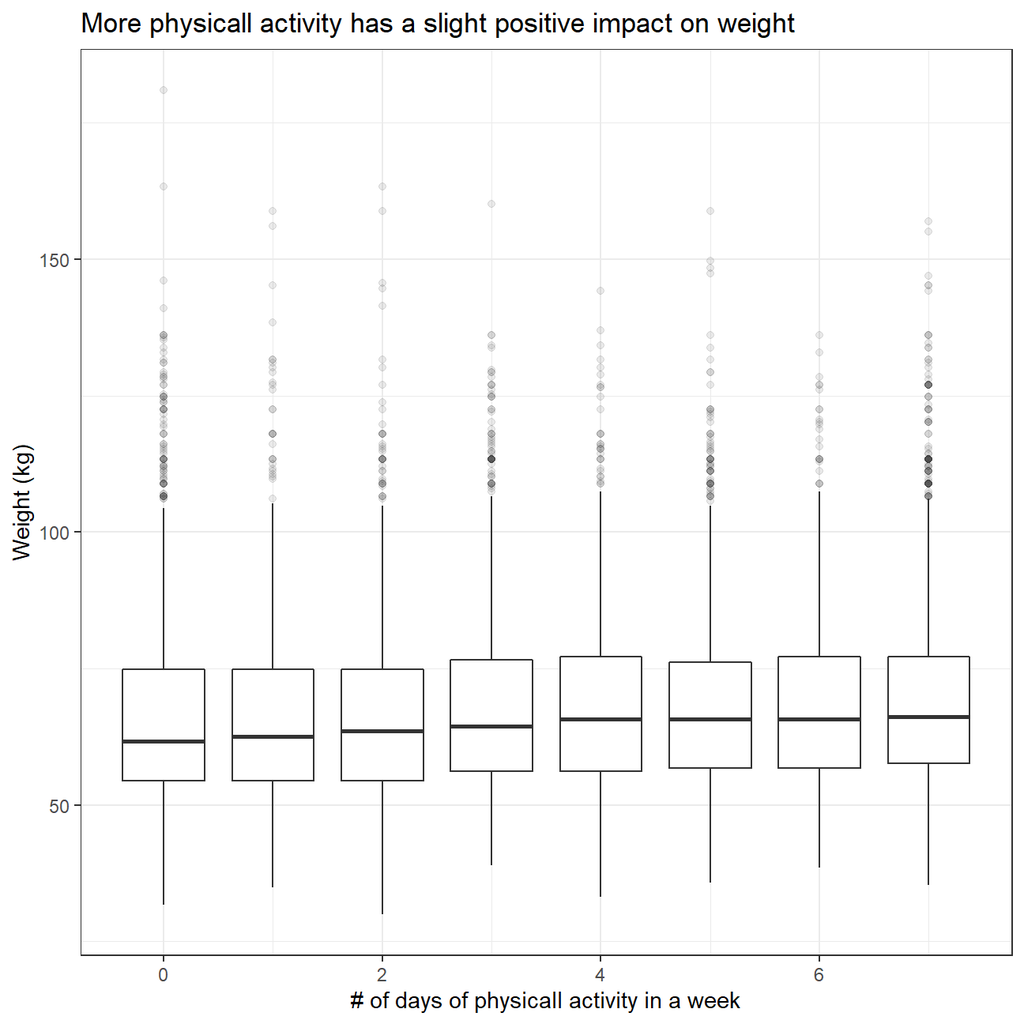

```r
ggplot(yrbss,aes(x=physically_active_7d,y=weight,na.rm=TRUE))+
geom_boxplot(aes(group = cut_width(physically_active_7d, 0.25)), outlier.alpha = 0.1)+
 labs (
    title= "More physicall activity has a slight positive impact on weight",
    x = "# of days of physicall activity in a week",
    y = "Weight (kg)"
  )+
theme_bw()+
NULL
```

Let’s create a new variable `physical_3plus`, which will be `yes` if they are physically active for at least 3 days a week, and `no` otherwise.

```r
yrbss <- yrbss %>%
  mutate(physical_3plus = ifelse(physically_active_7d >= 3, "yes", "no"))

yrbss %>% filter(!is.na(physical_3plus)) %>%
  group_by(physical_3plus) %>%
  summarise(count = n()) %>%
  mutate(prop= count/sum(count))
```

```
## # A tibble: 2 x 3
##   physical_3plus count  prop
##   <chr>          <int> <dbl>
## 1 no              4404 0.331
## 2 yes             8906 0.669
```

Can you provide a 95% confidence interval for the population proportion of high schools that are *NOT* active 3 or more days per week?

```r
formula_CI <- yrbss %>%
filter(!is.na(physical_3plus)) %>%

summarise(count_no=count(physical_3plus=="no"),
            total=n(),
            proportion_no=count_no/total,

lower_95_CI_no=proportion_no-1.96*sqrt(
              (proportion_no*(1-proportion_no))/total),

upper_95_CI_no=proportion_no+1.96*sqrt(
              (proportion_no*(1-proportion_no))/total))

formula_CI[4:5]
```

```
## # A tibble: 1 x 2
##   lower_95_CI_no upper_95_CI_no
##            <dbl>          <dbl>
## 1          0.323          0.339
```

Let’s show a boxplot of `physical_3plus` vs. `weight`. Is there a relationship between these two variables? What did you expect and why?

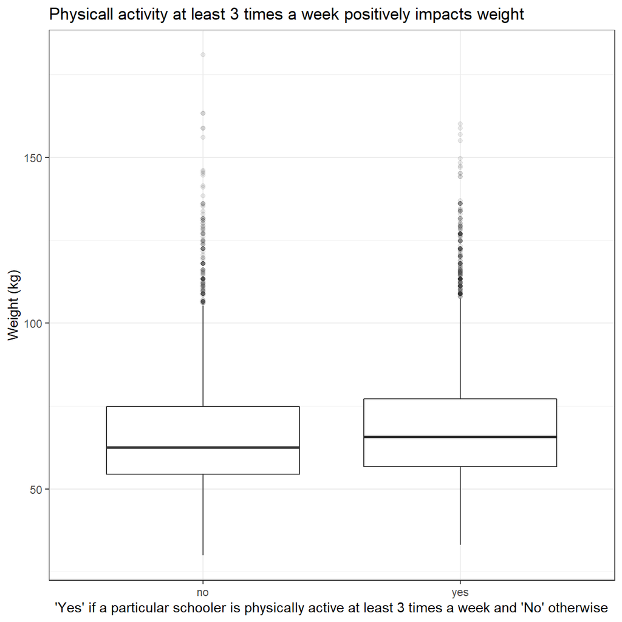

```r
yrbss %>%
filter(!is.na(physical_3plus)) %>%
  ggplot(aes(x=physical_3plus,y=weight))+
  geom_boxplot(outlier.alpha = 0.1)+
  labs (
    title= "Physicall activity at least 3 times a week positively impacts weight",
    x = "'Yes' if a particular schooler is physically active at least 3 times a week and 'No' otherwise",
    y = "Weight (kg)"
  )+
  theme_bw()+
  NULL
```

> I expected that being physically active at least 3 times a week will result in a lower weight as one would burn more calories, but from the graph it is evident that more physicall activity is positively correlated with weight.

## 1.3 Confidence Interval

Boxplots show how the medians of the two distributions compare, but we can also compare the means of the distributions using either a confidence interval or a hypothesis test.

```r
yrbss %>%
  group_by(physical_3plus) %>%
  filter(!is.na(physical_3plus)) %>%
  summarise(mean_weight = mean(weight, na.rm = TRUE),
            sd_weight = sd(weight, na.rm=TRUE),
            count = n(),
            se_weight = sd_weight/sqrt(count),
            t_critical = qt(0.975, count-1),
            margin_of_error = t_critical * se_weight,
            lower = mean_weight - t_critical * se_weight,
            upper = mean_weight + t_critical * se_weight
            )
```

```
## # A tibble: 2 x 9
##   physical_3plus mean_weight sd_weight count se_weight t_critical
##   <chr>                <dbl>     <dbl> <int>     <dbl>      <dbl>
## 1 no                    66.7      17.6  4404     0.266       1.96
## 2 yes                   68.4      16.5  8906     0.175       1.96
## # ... with 3 more variables: margin_of_error <dbl>, lower <dbl>, upper <dbl>
```

There is an observed difference of about 1.77kg (68.44 - 66.67), and we notice that the two confidence intervals do not overlap. It seems that the difference is at least 95% statistically significant. Let us also conduct a hypothesis test.

## 1.4 Hypothesis test with formula

Write the null and alternative hypotheses for testing whether mean weights are different for those who exercise at least times a week and those who don’t.

> Null hypotheses: true difference in mean weights for high schoolers who exercise at least 3 times a week and those who don’t is equal to 0

> Alternative hypotheses: true difference in mean weights is not equal to 0

```r
t.test(weight ~ physical_3plus, data = yrbss)
```

```
##
##  Welch Two Sample t-test
##
## data:  weight by physical_3plus
## t = -5, df = 7479, p-value = 9e-08
## alternative hypothesis: true difference in means is not equal to 0
## 95 percent confidence interval:
##  -2.42 -1.12
## sample estimates:
##  mean in group no mean in group yes
##              66.7              68.4
```

## 1.5 Hypothesis test with `infer`

We need to initialize the test, which we will save as `obs_diff`.

```r
obs_diff <- yrbss %>%
  specify(weight ~ physical_3plus) %>%
  calculate(stat = "diff in means", order = c("yes", "no"))
```

After we have initialized the test, we need to simulate the test on the null distribution, which we will save as null.

```r
null_dist <- yrbss %>%
  specify(weight ~ physical_3plus) %>%
  hypothesize(null = "independence") %>%
  generate(reps = 1000, type = "permute") %>%
  calculate(stat = "diff in means", order = c("yes", "no"))
```

We can visualize this null distribution with the following code:

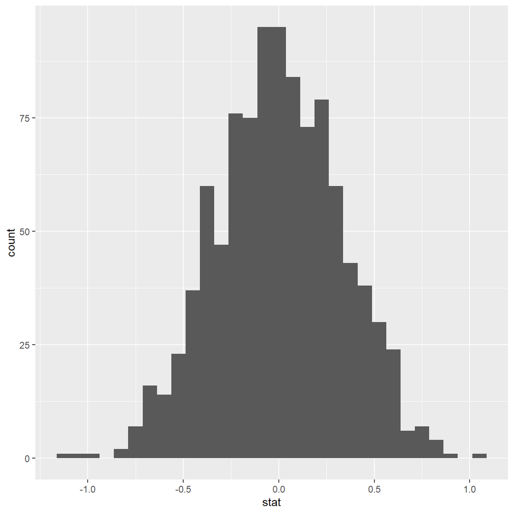

```r
ggplot(data = null_dist, aes(x = stat)) +
  geom_histogram()
```

Now that the test is initialized and the null distribution formed, we can visualise to see how many of these null permutations have a difference of at least `obs_stat` of 1.77?

We can also calculate the p-value for your hypothesis test using the function `infer::get_p_value()`.

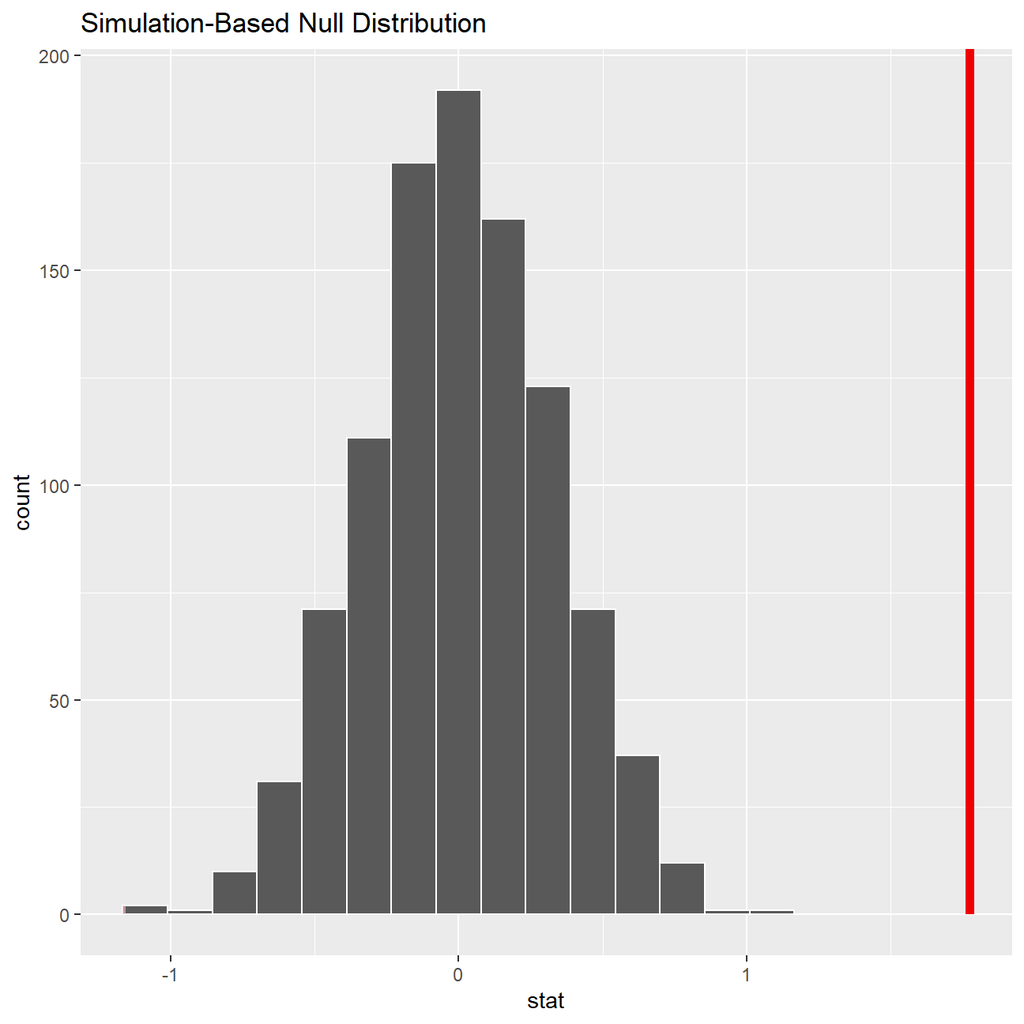

```r
null_dist %>% visualize() +
  shade_p_value(obs_stat = obs_diff, direction = "two-sided")
```

```r
null_dist %>%
  get_p_value(obs_stat = obs_diff, direction = "two_sided")
```

```
## # A tibble: 1 x 1
##   p_value
##     <dbl>
## 1       0
```

# 2 IMDB ratings: Differences between directors

Recall the IMBD ratings data. In this section we explore whether the mean IMDB rating for Steven Spielberg and Tim Burton are the same or not.

```r
knitr::include_graphics(here::here("images", "directors.png"))
```

[output not shown]

You can load the data and examine its structure

```r
#we examine the data
movies <- read_csv(here::here("data", "movies.csv"))
glimpse(movies)
```

```
## Rows: 2,961
## Columns: 11
## $ title               <chr> "Avatar", "Titanic", "Jurassic World", "The Ave...
## $ genre               <chr> "Action", "Drama", "Action", "Action", "Action"...
## $ director            <chr> "James Cameron", "James Cameron", "Colin Trevor...
## $ year                <dbl> 2009, 1997, 2015, 2012, 2008, 1999, 1977, 2015,...
## $ duration            <dbl> 178, 194, 124, 173, 152, 136, 125, 141, 164, 93...
## $ gross               <dbl> 7.61e+08, 6.59e+08, 6.52e+08, 6.23e+08, 5.33e+0...
## $ budget              <dbl> 2.37e+08, 2.00e+08, 1.50e+08, 2.20e+08, 1.85e+0...
## $ cast_facebook_likes <dbl> 4834, 45223, 8458, 87697, 57802, 37723, 13485, ...
## $ votes               <dbl> 886204, 793059, 418214, 995415, 1676169, 534658...
## $ reviews             <dbl> 3777, 2843, 1934, 2425, 5312, 3917, 1752, 1752,...
## $ rating              <dbl> 7.9, 7.7, 7.0, 8.1, 9.0, 6.5, 8.7, 7.5, 8.5, 7....
```

```r
#we check whether there are any duplicate entries
skim(movies)
```

Data summary

| Name | movies |
| --- | --- |
| Number of rows | 2961 |
| Number of columns | 11 |
| _______________________ |  |
| Column type frequency: |  |
| character | 3 |
| numeric | 8 |
| ________________________ |  |
| Group variables | None |

**Variable type: character**

| skim_variable | n_missing | complete_rate | min | max | empty | n_unique | whitespace |
| --- | --- | --- | --- | --- | --- | --- | --- |
| title | 0 | 1 | 1 | 83 | 0 | 2907 | 0 |
| genre | 0 | 1 | 5 | 11 | 0 | 17 | 0 |
| director | 0 | 1 | 3 | 32 | 0 | 1366 | 0 |

**Variable type: numeric**

| skim_variable | n_missing | complete_rate | mean | sd | p0 | p25 | p50 | p75 | p100 | hist |
| --- | --- | --- | --- | --- | --- | --- | --- | --- | --- | --- |
| year | 0 | 1 | 2.00e+03 | 9.95e+00 | 1920.0 | 2.00e+03 | 2.00e+03 | 2.01e+03 | 2.02e+03 | ▁▁▁▂▇ |
| duration | 0 | 1 | 1.10e+02 | 2.22e+01 | 37.0 | 9.50e+01 | 1.06e+02 | 1.19e+02 | 3.30e+02 | ▃▇▁▁▁ |
| gross | 0 | 1 | 5.81e+07 | 7.25e+07 | 703.0 | 1.23e+07 | 3.47e+07 | 7.56e+07 | 7.61e+08 | ▇▁▁▁▁ |
| budget | 0 | 1 | 4.06e+07 | 4.37e+07 | 218.0 | 1.10e+07 | 2.60e+07 | 5.50e+07 | 3.00e+08 | ▇▂▁▁▁ |
| cast_facebook_likes | 0 | 1 | 1.24e+04 | 2.05e+04 | 0.0 | 2.24e+03 | 4.60e+03 | 1.69e+04 | 6.57e+05 | ▇▁▁▁▁ |
| votes | 0 | 1 | 1.09e+05 | 1.58e+05 | 5.0 | 1.99e+04 | 5.57e+04 | 1.33e+05 | 1.69e+06 | ▇▁▁▁▁ |
| reviews | 0 | 1 | 5.03e+02 | 4.94e+02 | 2.0 | 1.99e+02 | 3.64e+02 | 6.31e+02 | 5.31e+03 | ▇▁▁▁▁ |
| rating | 0 | 1 | 6.39e+00 | 1.05e+00 | 1.6 | 5.80e+00 | 6.50e+00 | 7.10e+00 | 9.30e+00 | ▁▁▆▇▁ |

```r
#there are fewer unique titles than rows, so we need to take rid of duplicate entries
movies_cleaned <-movies %>%
  distinct(title, .keep_all = TRUE)

#we check the dataset again, to see whether issue has been corrected
skim(movies_cleaned)
```

Data summary

| Name | movies_cleaned |
| --- | --- |
| Number of rows | 2907 |
| Number of columns | 11 |
| _______________________ |  |
| Column type frequency: |  |
| character | 3 |
| numeric | 8 |
| ________________________ |  |
| Group variables | None |

**Variable type: character**

| skim_variable | n_missing | complete_rate | min | max | empty | n_unique | whitespace |
| --- | --- | --- | --- | --- | --- | --- | --- |
| title | 0 | 1 | 1 | 83 | 0 | 2907 | 0 |
| genre | 0 | 1 | 5 | 11 | 0 | 17 | 0 |
| director | 0 | 1 | 3 | 32 | 0 | 1366 | 0 |

**Variable type: numeric**

| skim_variable | n_missing | complete_rate | mean | sd | p0 | p25 | p50 | p75 | p100 | hist |
| --- | --- | --- | --- | --- | --- | --- | --- | --- | --- | --- |
| year | 0 | 1 | 2.00e+03 | 9.92e+00 | 1920.0 | 2.00e+03 | 2.00e+03 | 2.01e+03 | 2.02e+03 | ▁▁▁▂▇ |
| duration | 0 | 1 | 1.10e+02 | 2.23e+01 | 37.0 | 9.50e+01 | 1.05e+02 | 1.19e+02 | 3.30e+02 | ▃▇▁▁▁ |
| gross | 0 | 1 | 5.76e+07 | 7.23e+07 | 703.0 | 1.20e+07 | 3.45e+07 | 7.51e+07 | 7.61e+08 | ▇▁▁▁▁ |
| budget | 0 | 1 | 4.02e+07 | 4.32e+07 | 218.0 | 1.10e+07 | 2.50e+07 | 5.50e+07 | 3.00e+08 | ▇▂▁▁▁ |
| cast_facebook_likes | 0 | 1 | 1.23e+04 | 2.05e+04 | 0.0 | 2.22e+03 | 4.54e+03 | 1.68e+04 | 6.57e+05 | ▇▁▁▁▁ |
| votes | 0 | 1 | 1.09e+05 | 1.59e+05 | 5.0 | 1.95e+04 | 5.47e+04 | 1.32e+05 | 1.69e+06 | ▇▁▁▁▁ |
| reviews | 0 | 1 | 4.98e+02 | 4.93e+02 | 2.0 | 1.97e+02 | 3.58e+02 | 6.24e+02 | 5.31e+03 | ▇▁▁▁▁ |
| rating | 0 | 1 | 6.39e+00 | 1.06e+00 | 1.6 | 5.80e+00 | 6.50e+00 | 7.10e+00 | 9.30e+00 | ▁▁▆▇▁ |

```r
#the chart we are supposed to reproduce is incorrect, as for Tim Burton it works with duplicate entries for Alice in Wonderland and Planet of Apes, we will use movies_cleaned instead of movies

#we create a new data set creating only useful rows of the two directors studied
useful_movies<-movies_cleaned %>%
  filter((director=="Steven Spielberg")|(director=="Tim Burton"))

#we use only useful data
director_confidence_interval<-useful_movies %>%
#thanks to previously filtering data we can group_by director to get useful output for both directors
  group_by(director)%>%
  summarise(movies=n(),
            mean=mean(rating,na.rm=TRUE),
            sd=sd(rating, na.rm=TRUE),
            lower=mean-abs(qt(0.025,(movies-1)))*(sd/sqrt(movies)),
            higher=mean+abs(qt(0.025,(movies-1)))*(sd/sqrt(movies)))

director_confidence_interval
```

```
## # A tibble: 2 x 6
##   director         movies  mean    sd lower higher
##   <chr>             <int> <dbl> <dbl> <dbl>  <dbl>
## 1 Steven Spielberg     23  7.57 0.695  7.27   7.87
## 2 Tim Burton           14  7.05 0.708  6.64   7.46
```

```r
NULL
```

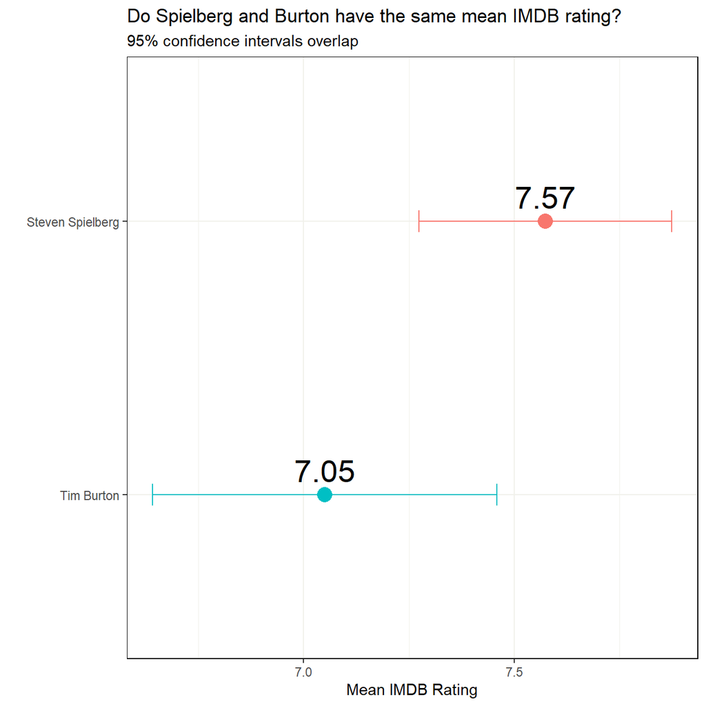

```r
#using table with calculations, setting order
ggplot(director_confidence_interval, aes(x=mean, y=reorder(director,mean), colour=director))+

  #plot mean
  geom_point(aes(size=1.4))+

  #plot confidence interval around mean
  geom_errorbarh(aes(xmax=higher, xmin=lower,
                     #this part is not recognized at all
                     width=0.08, thickness=6))+

  #set up titles and axes
  labs(title="Do Spielberg and Burton have the same mean IMDB rating?", subtitle="95% confidence intervals overlap", x= "Mean IMDB Rating", y= "" )+

  #remove legend
  theme(legend.position="none")+

  #setting background
  theme(strip.background = element_rect(
     color="black", fill="white", linetype="solid"), panel.background = element_rect(fill = "white"),panel.grid=element_line(size=0.5, colour="#F1F1EB"), panel.border = element_rect(fill=NA))+

  #placing labels, adjusting decimal place, size, position and colour
  geom_text(aes(label=round(mean, digits = 2)), size=7.5, nudge_y=0.09, colour="black")
```

We run hypothesis tests using both the `t.test` command and the `infer` package to simulate from a null distribution, where we assume zero difference between the two.

```r
# Getting p-value using t.test:

t.test(rating~director, data=useful_movies)
```

```
##
##  Welch Two Sample t-test
##
## data:  rating by director
## t = 2, df = 27, p-value = 0.04
## alternative hypothesis: true difference in means is not equal to 0
## 95 percent confidence interval:
##  0.0351 1.0127
## sample estimates:
## mean in group Steven Spielberg       mean in group Tim Burton
##                           7.57                           7.05
```

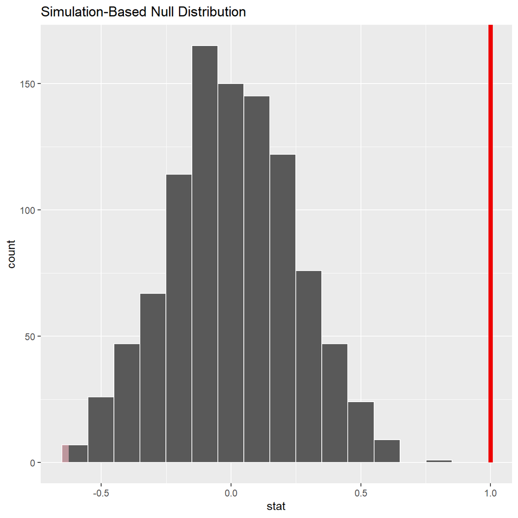

```r
# Getting p-value using infer:

# We randomize
set.seed(5648)

ratings_in_null_world<-useful_movies %>%

# Specify the variable of interest
specify(rating~director) %>%

# Hypothesize a null of no (or zero) difference
hypothesize(null = "independence") %>%

# Generate a bunch of simulated samples
generate(reps=1000 , type ="permute")%>%

# Find the mean difference of each sample
calculate(stat = "diff in means",
          order = c("Steven Spielberg", "Tim Burton"))


#visualize how extreme would the observed results be if we simulate a hypothesized population
ratings_in_null_world %>% visualize()+
   shade_p_value(obs_stat =ratings_in_null_world, direction = "both")
```

```r
#Calculate a p-value
ratings_in_null_world %>%
  get_pvalue(obs_stat= 0.52, direction = "both")
```

```
## # A tibble: 1 x 1
##   p_value
##     <dbl>
## 1   0.028
```

# 3 Omega Group plc- Pay Discrimination

At the last board meeting of Omega Group Plc., the headquarters of a large multinational company, the issue was raised that women were being discriminated in the company, in the sense that the salaries were not the same for male and female executives. A quick analysis of a sample of 50 employees (of which 24 men and 26 women) revealed that the average salary for men was about 8,700 higher than for women. This seemed like a considerable difference, so it was decided that a further analysis of the company salaries was warranted.

## 3.1 Loading the data

```r
omega <- read_csv(here::here("data", "omega.csv"))
glimpse(omega) # examine the data frame
```

```
## Rows: 50
## Columns: 3
## $ salary     <dbl> 81894, 69517, 68589, 74881, 65598, 76840, 78800, 70033, ...
## $ gender     <chr> "male", "male", "male", "male", "male", "male", "male", ...
## $ experience <dbl> 16, 25, 15, 33, 16, 19, 32, 34, 1, 44, 7, 14, 33, 19, 24...
```

## 3.2 Relationship Salary - Gender ?

Calculation of Summary Statistics on salary by gender (mean, SD, sample size, the t-critical, the SE, the margin of error, and the low/high endpoints of a 95% condifence interval)

```r
mosaic::favstats (salary ~ gender, data=omega)
```

```
##   gender   min    Q1 median    Q3   max  mean   sd  n missing
## 1 female 47033 60338  64618 70033 78800 64543 7567 26       0
## 2   male 54768 68331  74675 78568 84576 73239 7463 24       0
```

```r
#assign name to dataframe

salary_stats<- omega %>%

#group data by gender

group_by(gender) %>%

#calculate statistics

summarise(mean_salary=mean(salary),

          Standard_Deviation=sd(salary),

          Sample_Size=n(),

          t_criticial=qt(0.05/2,Sample_Size-1),

          Standard_Error=(Standard_Deviation/sqrt(Sample_Size)),

          margin_of_error=Standard_Error*t_criticial,

          CI_high=mean_salary+margin_of_error,

          CI_low=mean_salary-margin_of_error)

salary_stats
```

```
## # A tibble: 2 x 9
##   gender mean_salary Standard_Deviat~ Sample_Size t_criticial Standard_Error
##   <chr>        <dbl>            <dbl>       <int>       <dbl>          <dbl>
## 1 female      64543.            7567.          26       -2.06          1484.
## 2 male        73239.            7463.          24       -2.07          1523.
## # ... with 3 more variables: margin_of_error <dbl>, CI_high <dbl>, CI_low <dbl>
```

Let’s visualise these values

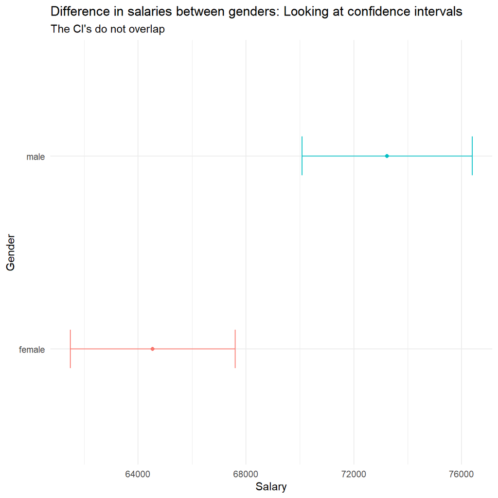

```r
ggplot(salary_stats,

       aes(x=reorder(gender, mean_salary),
           y=mean_salary,
           colour=gender)) +

  geom_point() +

  geom_errorbar(width=.2, aes(ymin=CI_low, ymax=CI_high)) +

  labs(x="Gender",
       y= "Salary",
       title= "Difference in salaries between genders: Looking at confidence intervals",
       subtitle = "The CI's do not overlap")+

  theme_minimal()+

  coord_flip()+

  theme(legend.position = "none")+

  NULL
```

Conclusion

The confidence Intervals do not overlap. Thus with 95% confidence we can conclude that there is a difference in population means between male and females salaries.

Another way of determining whether the difference in salaries is significant is to test the null hypothesis=

Mean difference in salaries is zero.

We can test this using 1) t.test() and 2) the simulation method from the infer package

1. hypothesis testing using t.test()

```r
# first we have to check whether the populations have an equal or unequal variance using the Barlett test

salary_variance <- bartlett.test(salary ~ gender,
        data = omega)

salary_variance
```

```
##
##  Bartlett test of homogeneity of variances
##
## data:  salary by gender
## Bartlett's K-squared = 0.005, df = 1, p-value = 0.9
```

```r
# Since the p-value is higher than 0.05, we can assume that they have equal variances.

# use t.test for equal variances
t_test <- t.test(salary~gender,
                 data = omega,
                 var.equal = TRUE)

t_test
```

```
##
##  Two Sample t-test
##
## data:  salary by gender
## t = -4, df = 48, p-value = 2e-04
## alternative hypothesis: true difference in means is not equal to 0
## 95 percent confidence interval:
##  -12975  -4418
## sample estimates:
## mean in group female   mean in group male
##                64543                73239
```

```r
t_test_tidy <- tidy(t_test) %>%

  # Calculate difference in means, since t.test() doesn't actually do that

  mutate(estimate = estimate1 - estimate2) %>%

  # Rearrange columns

  select(starts_with("estimate"), everything())

t_test_tidy
```

```
## # A tibble: 1 x 10
##   estimate estimate1 estimate2 statistic p.value parameter conf.low conf.high
##      <dbl>     <dbl>     <dbl>     <dbl>   <dbl>     <dbl>    <dbl>     <dbl>
## 1   -8696.    64543.    73239.     -4.09 1.65e-4        48  -12975.    -4418.
## # ... with 2 more variables: method <chr>, alternative <chr>
```

2. Hypothesis testing using infer package

```r
null_distribution <- omega %>%

# specify response variable and explanatory variable
  specify(salary~gender) %>%

# hypothesize H0 (use independence because we have two samples)

  hypothesize(null="independence") %>%

# generate replicates

  generate(reps=1000, type="permute") %>%

# calculate summary statistics

  calculate(stat = "diff in means", order = c("male","female"))

null_distribution
```

```
## # A tibble: 1,000 x 2
##    replicate   stat
##        <int>  <dbl>
##  1         1  1184.
##  2         2  3911.
##  3         3 -1824.
##  4         4 -2651.
##  5         5  2969.
##  6         6 -3808.
##  7         7  2258.
##  8         8   250.
##  9         9 -2750.
## 10        10  2622.
## # ... with 990 more rows
```

```r
# visualize the p-value

obs_diff_means <- omega %>%
  specify(salary~gender) %>%
  calculate(stat = "diff in means", order = c("male","female"))

actual_difference <- obs_diff_means  %>% pull()

obs_diff_means
```

```
## # A tibble: 1 x 1
##    stat
##   <dbl>
## 1 8696.
```

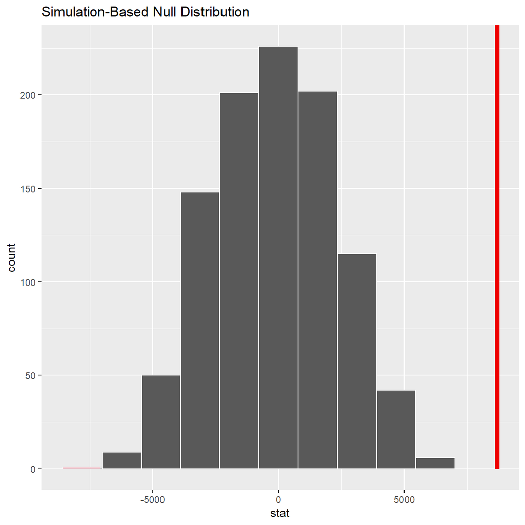

```r
  visualize(null_distribution, bins =10)+

  shade_p_value(obs_stat =obs_diff_means, direction = "both")
```

```r
obs_diff_means %>%
  get_p_value(obs_stat = 8696,direction = "both")
```

```
## # A tibble: 1 x 1
##   p_value
##     <dbl>
## 1       0
```

Conclusion:

Both methods show us that with 95% confidence we can say that there is a statistically significant difference in salaries between men and women.

- the t.test method shows a p value < 0.05 (the difference in means we observed is highly surprising in a world where h0 holds true) a t value whose absolute value is higher than 2, and the confidence interval does not include 0
- the infer method shows that the probability of an observed difference in means of about 8697 is very unlikely where H0=there is no difference in means between genders holds true with p value = 0

## 3.3 Relationship Experience - Gender?

At the board meeting, someone raised the issue that there was indeed a substantial difference between male and female salaries, but that this was attributable to other reasons such as differences in experience. A questionnaire send out to the 50 executives in the sample reveals that the average experience of the men is approximately 21 years, whereas the women only have about 7 years experience on average (see table below).

```r
# Summary Statistics of salary by gender
favstats (experience ~ gender, data=omega)
```

```
##   gender min    Q1 median   Q3 max  mean    sd  n missing
## 1 female   0  0.25    3.0 14.0  29  7.38  8.51 26       0
## 2   male   1 15.75   19.5 31.2  44 21.12 10.92 24       0
```

First let’s have a look at the data

```r
# assign name to dataframe

experience_stats<- omega %>%

# group data by gender

group_by(gender) %>%

# calculate statistics

summarise(mean_experience=mean(experience),

          Standard_Deviation=sd(experience),

          Sample_Size=n(),

          t_criticial=qt(0.05/2,Sample_Size-1),

          Standard_Error=(Standard_Deviation/sqrt(Sample_Size)),

          margin_of_error=Standard_Error*t_criticial,

          CI_high=mean_experience+margin_of_error,

          CI_low=mean_experience-margin_of_error)

experience_stats
```

```
## # A tibble: 2 x 9
##   gender mean_experience Standard_Deviat~ Sample_Size t_criticial Standard_Error
##   <chr>            <dbl>            <dbl>       <int>       <dbl>          <dbl>
## 1 female            7.38             8.51          26       -2.06           1.67
## 2 male             21.1             10.9           24       -2.07           2.23
## # ... with 3 more variables: margin_of_error <dbl>, CI_high <dbl>, CI_low <dbl>
```

Let’s visualise this

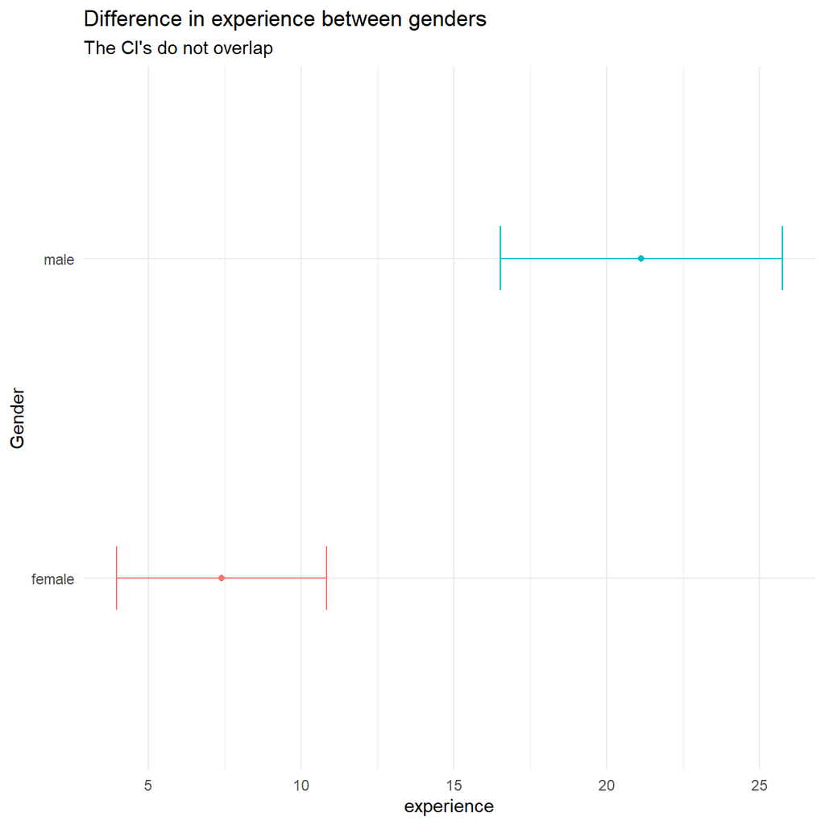

```r
ggplot(experience_stats,
       aes(x=reorder(gender, mean_experience),
           y=mean_experience,
           colour=gender))+

  geom_point() +

  geom_errorbar(width=.2, aes(ymin=CI_low, ymax=CI_high)) +

  labs(x="Gender",
       y= "experience",
       title="Difference in experience between genders",
       subtitle = "The CI's do not overlap") +

  theme_minimal()+

  coord_flip()+

  theme(legend.position = "none")+

  NULL
```

Now let’s do the hypothesis testing, first using t.test()

```r
# first we have to check whether the populations have an equal or unequal variance usng the Barlett test

exp_variance <- bartlett.test(experience ~ gender,
        data = omega)

exp_variance
```

```
##
##  Bartlett test of homogeneity of variances
##
## data:  experience by gender
## Bartlett's K-squared = 1, df = 1, p-value = 0.2
```

```r
# Since the p-value is higher than 0.05, we can assume that they have equal variances.

# use t.test for equal variances

t_test_exp <- t.test(experience~gender,
                 data = omega,
                 var.equal = TRUE)

t_test_exp
```

```
##
##  Two Sample t-test
##
## data:  experience by gender
## t = -5, df = 48, p-value = 9e-06
## alternative hypothesis: true difference in means is not equal to 0
## 95 percent confidence interval:
##  -19.3  -8.2
## sample estimates:
## mean in group female   mean in group male
##                 7.38                21.12
```

```r
t_test_exp_tidy <- tidy(t_test_exp) %>%

  # Calculate difference in means, since t.test() doesn't actually do that

  mutate(estimate = estimate1 - estimate2) %>%

  # Rearrange columns

  select(starts_with("estimate"), everything())

t_test_exp_tidy
```

```
## # A tibble: 1 x 10
##   estimate estimate1 estimate2 statistic p.value parameter conf.low conf.high
##      <dbl>     <dbl>     <dbl>     <dbl>   <dbl>     <dbl>    <dbl>     <dbl>
## 1    -13.7      7.38      21.1     -4.98 8.51e-6        48    -19.3     -8.20
## # ... with 2 more variables: method <chr>, alternative <chr>
```

Now with the infer package

```r
null_distribution_exp <- omega %>%

# specify response variable and explanatory variable
  specify(experience~gender) %>%

# hypothesize H0 (use independence because we have only one dataset)

  hypothesize(null="independence") %>%

# generate replicates

  generate(reps=1000, type="permute") %>%

# calculate summary statistics

  calculate(stat = "diff in means", order = c("male","female"))

null_distribution
```

```
## # A tibble: 1,000 x 2
##    replicate   stat
##        <int>  <dbl>
##  1         1  1184.
##  2         2  3911.
##  3         3 -1824.
##  4         4 -2651.
##  5         5  2969.
##  6         6 -3808.
##  7         7  2258.
##  8         8   250.
##  9         9 -2750.
## 10        10  2622.
## # ... with 990 more rows
```

```r
# Visualize p value

obs_diff_means_exp <- omega %>%

  specify(experience~gender) %>%

  calculate(stat = "diff in means", order = c("male","female"))

obs_diff_means_exp
```

```
## # A tibble: 1 x 1
##    stat
##   <dbl>
## 1  13.7
```

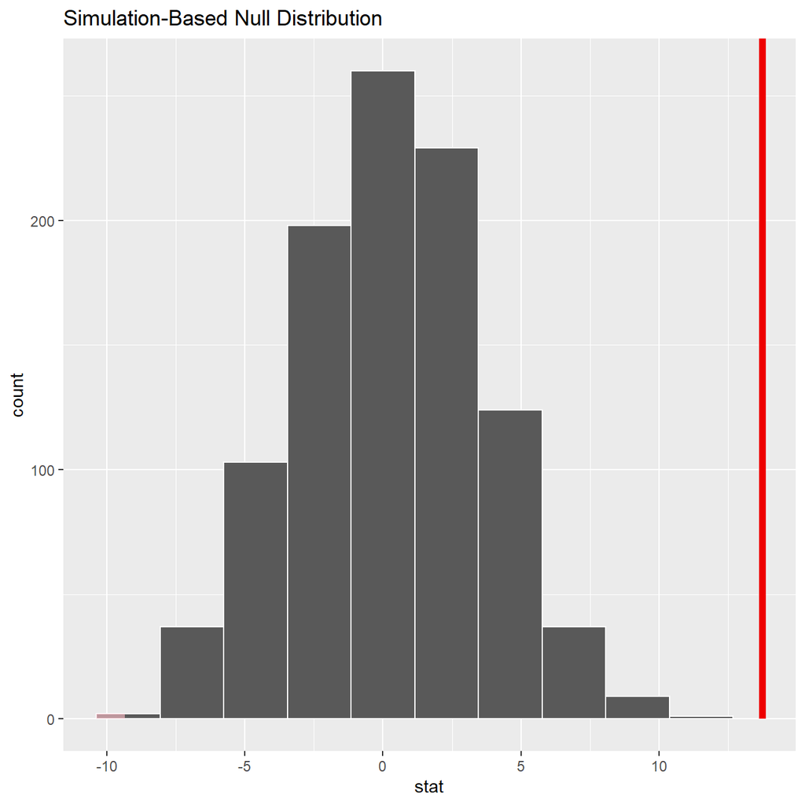

```r
  visualize(null_distribution_exp, bins =10)+

  shade_p_value(obs_stat =obs_diff_means_exp, direction = "both")
```

```r
obs_diff_means %>%
  get_p_value(obs_stat = obs_diff_means_exp, direction = "both")
```

```
## # A tibble: 1 x 1
##   p_value
##     <dbl>
## 1       0
```

Conclusion:

Both methods show us that there is a statistically significant difference in experience between men and women

- summary statistics show that the confidence intervals do not overlap
- the t.test method shows a p value < 0.05, a t value whose absolute value is higher than 2, and the confidence interval does not include 0
- the infer method shows that the probability of an observed difference in means of about 14 years is very unlikely (p value = 0) when H0=there is no difference in experience between genders holds true

There is still a significant difference in female and male salaries, however, this additional analysis shows that this difference is partly caused by the higher years of experience of the male executives. Overall, it weakens the argument that the difference in pay is solely due to discrimination.

## 3.4 Relationship Salary - Experience ?

Let’s have a closer look at the relationship between experience in salary using a scatter plot

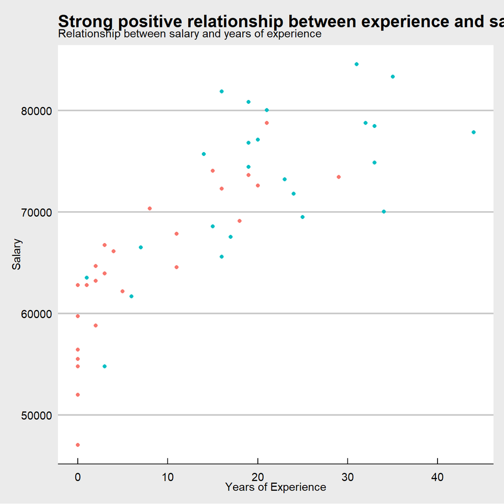

```r
# create plot from data omega where x axis shows experience, and y axis shows salary

ggplot(omega, aes(x = experience, y=salary,color=gender))+

# use geom_point to create a scatterplot

  geom_point()+

# add a theme and labels

  theme_economist_white()+

  labs(
    title = "Strong positive relationship between experience and salary",
    subtitle = "Relationship between salary and years of experience",
    x ="Years of Experience",
    y ="Salary")+

  # remove legend

  theme(legend.position = "none")+

  NULL
```